# Statistical analysis of measured larvael feeding strike rates

2023-10-23

# Statistical analysis of measured larvael feeding strike rates

## Introduction

This is an R Markdown to reproduce the statiscal analyses performed in: Bar, S., L. Levy, S. Avidan, and R. Holzman (2023).  
Assessing the determinants of larval fish strike rates using computer vision.  
Ecological Informatics 77, 102195. https://doi.org/10.1016/j.ecoinf.2023.102195

The aim of our analyses is: a. To ascertain that we sampled sufficiently in order to accurately characterize the larval strike rates. b. To asses the effect of environmental factors (temperature, $O_2$ saturation and pH level) on these rates.

Our data consist in estimations of larval feeding strike rates from 5-minute long high-speed (500 frames-per-second) video sequences captured in aquaculture rearing pools. The videos capture the natural variance of the rearing pool environment, featuring varying densities of fish, prey and water turbidity. Additional variance is introduced by differences in the filming setup and lighting between each filming session.

Larval feeding strike rates were estimated using an AI-assisted pipeline based on detection followed by action classification. The pipeline was applied in a sliding window manner throughout 223 videos from 17 different cohorts. Estimating these rates is difficult since these behaviors are extremely sparse - the number of observed strikes was low (on average, less then one per video). Furthermore, since our pipeline performance far surpassed that of a human annotator (finding twice as many events in the same sequences), we cannot be sure what is the “ground truth” strike rate. To asses whether we sampled sufficiently to accurately we performed a bootstrap.

To estimate how the variable environment of the rearing pool effected estimated rates, we used a zero-inflated negative binomial to model the rate estimates (per fish per hour) as a function of temperature, $O_2$ and pH as measured in the pools during filming.

Below you’ll find code for the bootstrap followed by the models. All data used in these analyses is free to download from our GitHub repo.

## Bootstrap

We’ll first load some necessary libraries and define some functions that will be used down the line.

–

**Some libraries and custom functions**

```r
library(data.table)
library(dplyr)
library(pscl) #for zero-inflated models
```

```r
library(RColorBrewer)
library(visreg)
library(ggplot2)
library(ggeffects)

# utility funcs
get_segment_indices = function(fps,sample_duration,seg_length=20,start_frame=0){
  #seg length in seconds
  step_size = seg_length*fps
  starts = seq(start_frame,sample_duration,step_size)
  ends = starts+step_size
  last = sample_duration - starts[[length(starts)]]
  ends[[length(ends)]] = sample_duration
  return(list(starts, ends))
}

get_rate_estimate = function(data_df,vidname,start_frame, end_frame, fps) {
  vid_sub = data_df %>%
    filter(vid_name==vidname &  (frame)<=(end_frame) & (frame)>(start_frame)) %>%
    filter(slowfast_ssv2pretrain_epoch49_strike_scores>0.75)%>%
    filter(!is_double)
  #clips create from frame_num+40 might also include frame number frame num
  duration = (end_frame-start_frame)/fps/60#calculate the duration in minutes
  num_events = sum(vid_sub$reviewer_label=='Strike')
  stats = list('num_events'=num_events, 'duration'=duration)
  return(stats)
}

# get zero inflated model for bootstrap:
get_model <- function(sampled.data){
  m <- tryCatch(withCallingHandlers(zeroinfl(sr~age_group|mean_dens,dist='negbin', data=sampled.data),
                error=function(cond){
                  message(paste('The following sample size was too zero-ie',
                                nrow(sampled.data)))
                  #message(paste('The sum of sr was', sum(sampled.data$sr)))
                  #message(cond)
                  return(NA)
                },
                warning=function(cond){
                  #message('fit hit an issue')
                  message(paste('fit issue sample size was',
                                nrow(sampled.data)))
                  #message(paste('The sum of sr was', sum(sampled.data$sr)))
                  #invokeRestart("muffleWarning")
                  return(NA)
                  #return(suppressWarnings(zeroinfl(sr~age_group|mean_dens,dist='negbin', data=sampled.data)))
                }
                ), error = function(e){return(NA)})
  return(m)
}

# Sample segments summing to a specified duration making sure all age groups are represented:
get_sampled = function(df, time){
  not.four = T
  while(not.four){
    inds = sample(seq(1,nrow(df)),time,replace = T)
    sampled = df[inds,c('num_events','duration','mean_dens','rate','age_group')]
    not.four = length(unique(sampled$age_group))!=4
  }
  return(sampled)
}
```

```r
# all predictions, each row is a clip:
all_preds = read.csv('all_reviewed_preds_ssv_and_kinetics.csv', stringsAsFactors = T)

# metadata for each long untrimmed video sequence
all_logs = read.csv('clean_imputed_video_metadata.csv', stringsAsFactors = T) #we use a clean version of the video log - we removed a problematic cohorts and very young/old ages that weren't sufficiently represented in the data. See the data cleaning and imputation section below

# take only preds belonging to videos in the metadata
filtered.all.preds = all_preds %>%
  filter(vid_name %in% all_logs$video_name)

# is double is a marker stating whether the same fish was viewed in two clips (clips are slightly overlapping temporally/spatially)
all_preds$is_double = as.logical(all_preds$is_double)
```

```r
counter=0
vid_names = unique(all_logs$video_name)
# create a new dataframe for the segments:
df = data.frame(vid_name=character(),
                fps = integer(),
                first_frame=integer(),
                last_frame=integer(),
                duration = double(),
                num_events = integer(),
                mean_density = double(),
                rate = double()
                )
# calculate the segments:
for (vidname in vid_names) {
  # get video metadata :
  fps = all_logs[all_logs$video_name==vidname,'fps']
  sample_duration = floor(all_logs[all_logs$video_name==vidname, "last_frame_labeled"])
  mean_density = all_logs[all_logs$video_name==vidname, "mean_detections_per_frame_20"]
  start_frame = all_logs[all_logs$video_name==vidname,'start_frame']
  age_group = all_logs[all_logs$video_name==vidname,'age_group']

  # get the segment indices (start and end frame for each segment):
  seg_ind = get_segment_indices(fps, sample_duration, seg_length = 20,
                                start_frame=start_frame)
  starts = seg_ind[[1]]
  ends = seg_ind[[2]]
  # iterate over all segments:
  for(i in seq(1,length(starts))){
    start = starts[[i]]
    end = ends[[i]]
    rate_stats = get_rate_estimate(all_preds,vidname, start, end, fps)
    entry = list(vid_name=vidname,
                fps = fps,
                first_frame=start,
                last_frame=end,
                duration = rate_stats$duration,
                num_events = rate_stats$num_events,
                mean_dens = mean_density,
                rate = rate_stats$num_events/(rate_stats$duration*mean_density),
                age_group = age_group
                )
    df = rbind(df,entry)
  }
}

write.csv(df,'test_segments_for_bootstrap.csv')
```

Using these segments we can now bootstrap the rates by randomly sampling these segments. We can then ask how will the rates change as a function of sampling efforts - will sampling more segments change the strike rate estimate? Initially we bootstrapped the raw event rates. However, since our data is severely zero-inflated, we have come to the conclusion that a better approach would be to bootstrap the rates estimates of zero-inflated model, one that takes into account the processes that might lead to false negatives resulting from low density and potential differences between age groups. So, instead of calculating the raw rates for each sample drawn, we simply use the sample to create a zero inflated negative binomial model of strike rate per hour per fish as a function of age group (counts, Negative Binomial part) and mean density (structural zeros, Bernoulli part).

Note that running the bootstrap will take some time

```r
#all_logs = read.csv('all_reviewed_logs_ssv_and_kinetics_imputed_noF04_noyoung.csv')
df =  read.csv('test_segments_for_bootstrap.csv', stringsAsFactors = T)
df[which(is.na(df$rate)),'rate']=0 # deal with zero divided values
# pre-define some variables:
pop_size = 200# how many times to run the bootstrap
# Note: for the paper I ran this with pop_size = 1000, however this takes a night to run (on a laptop)
set.seed(42)
times = seq(10,sum(df$duration),3)*3 #we multiply by 3 because each segment is 0.33333 min, we want round minutes so we need to sample more
times = round(times)
rates_pop =list()
ci= list()
groups = unique(df$age_group)
# pre-assign some containers:
for (counter in seq(1,length(groups))){
  rates_pop[[counter]] = matrix(rep(0,pop_size*length(times)), nrow=length(times),ncol=pop_size)
  ci[[counter]] = matrix(rep(NA, length(times)*2),ncol=2)
}

#loop through all durations of time to sample and run bootstrap pop_size times:
for (t in seq(length(times),1,by=-1)){
  print(t)
  for (i in seq(1,pop_size)){
    sampled = get_sampled(df,times[t]) # sample some segments
    sampled$sr = round(60*(sampled$num_events/(sampled$duration*sampled$mean_dens)))#sr = strike rate per fish per second
    sampled[which(is.na(sampled$sr)),'sr']=0
    model = get_model(sampled) # get a zero-inflated model based on these sampleed segments
    # get estimated rates from the model for each age group:
    for (counter in seq(1,length(groups))){
      if (length(is.na(model))>1){
        # first age group is the intercept, other groups are coeff+intercept
        if (counter!=1){
          rate = model$coefficients[[1]][[1]]+model$coefficients[[1]][[counter]]
          } else {
            rate = model$coefficients[[1]][[1]]
          }
      } else { rate=NA }
      # store rate in matrix:
      rates_pop[[counter]][t,i] = rate
      }
  }
  # calculate confidence intervals across the bootstrapped population:
  for (counter in seq(1,length(groups))){
    ci[[counter]][t,1:2] = quantile(rates_pop[[counter]][t,],probs=c(0.025,0.975),na.rm=T)
  }
}
```

Now that we have the bootstrap result let’s summarize them and do some visualizations:

```r
rates_pop_df = as.data.frame(do.call(rbind, rates_pop))
cis = as.data.frame(do.call(rbind, ci))

stat_df = data.frame(group=c(rep(levels(groups)[1],length(times)),
                             rep(levels(groups)[2],length(times)),
                             rep(levels(groups)[3],length(times)),
                             rep(levels(groups)[4],length(times))),
                     time = times/3,
                     mean_rate = rowMeans(rates_pop_df,na.rm = T),
                     lower_ci = cis[,1],
                     upper_ci = cis[,2])

stat_df$group = as.factor(stat_df$group)

# calculate the percent of the ci from the mean:

stat_df=stat_df %>%
  mutate(percent_mean_upper = (upper_ci-mean_rate)/mean_rate,
         percent_mean_lower = ifelse(lower_ci>=0,(mean_rate-(lower_ci))/mean_rate,
         (abs(lower_ci)-mean_rate)/mean_rate))%>%
  mutate(mean_percent_mean = (percent_mean_upper+percent_mean_lower)/2)

#get cuttoff for when ci arrives at 15% of the mean, for each age group:
cutoffs_mean= list()
cutoffs_upper= list()
cutoffs_lower = list()
ys = list()

for (counter in seq(1,length(groups))){
  sub_df = subset(stat_df, stat_df$group==levels(groups)[counter])
  print(nrow(sub_df))
  # we use a rolling mean to calculate the cutoffs to smooth out some of the noise
  ind = which(frollmean(sub_df$mean_percent_mean,3)<=0.15)[1]
  cutoffs_mean[[counter]] = rep(sub_df[ind,'time'],nrow(sub_df))
  ind = which(frollmean(sub_df$percent_mean_upper,3)<=0.15)[1]
  cutoffs_upper[[counter]] = rep(sub_df[ind,'time'],nrow(sub_df))
  ind = which(frollmean(sub_df$percent_mean_lower,3)<=0.15)[1]
  cutoffs_lower[[counter]] = rep(sub_df[ind,'time'],nrow(sub_df))
  ys[[counter]] = seq(0,1.5,length.out=nrow(sub_df))
}
```

```
## [1] 329
## [1] 329
## [1] 329
## [1] 329
```

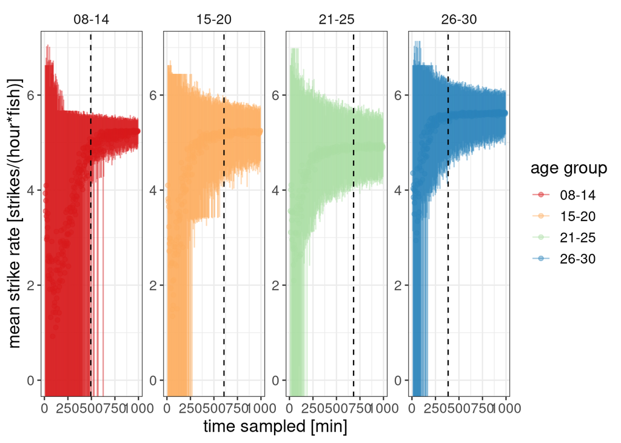

```r
stat_df$cutoff_mean = do.call(c,cutoffs_mean)
stat_df$cutoff_upper = do.call(c,cutoffs_upper)
stat_df$cutoff_lower = do.call(c,cutoffs_lower)
stat_df$y_for_percent = do.call(c,ys)


# Aaaand plot:

g = ggplot(data=stat_df)+geom_point(aes(x=time, y=mean_rate,color=group),alpha=0.4)+
  geom_errorbar(aes(x=time, ymin=lower_ci, ymax=upper_ci,color=group),
                width=0.25,alpha=0.45)+
  # Add vertical line showing the sample duration above which CI is under 15% of the mean rate:
  geom_vline(aes(xintercept=cutoff_mean),linetype='dashed') +
  coord_cartesian(ylim=c(0,7))+
  scale_color_brewer(palette='Spectral',name='age group')+
  labs(x='time sampled [min]', y='mean strike rate [strikes/(hour*fish)]')+
  theme_bw()+
  theme(strip.background = element_blank(),text = element_text(size=14))+
  facet_wrap(.~group,scales="free",nrow=1)

# Save figure and bootstrapped rates (this is figure 4 is the paper):
#ggsave('test_boot_by_group.pdf',plot=g,width = 11, height=5)
#write.csv(stat_df, 'bootstrap_pop200.csv')
g
```

## Environmental effects on strike rates

### Data imputation and cleaning:

For the statistical analysis on the effects of environmental factors we needed to to do some data cleaning and imputation of missing values. With data cleaning, we decided to remove ages below 8DPH and above 30DPH from analysis due to insufficient samples.

```r
all_logs = read.csv('all_reviewed_logs_ssv_and_kinetics.csv')
nrow(all_logs)
# remove older ages:
data = all_logs[-which(all_logs$DPH>30),]
nrow(data)
# and too young ages:
data = data[-which(data$DPH<8),]
nrow(data)
# remove PH outliers, calc mean, impute all missing values and replace with mean
values_to_remove = c(which(data$PH<=7.2),which(data$PH>=8.5))
data[values_to_remove,'PH'] = NA
# calc mean for both oxygen and PH
mean.oxygen = mean(data$oxygen,na.rm=T)
mean.PH = mean(data$PH,na.rm=T)
# impute missing values:
data[which(is.na(data$oxygen)),'oxygen'] = mean.oxygen
data[which(is.na(data$PH)),'PH'] = mean.PH
data$stat_strikes = (data$manual_strikes-data$manual_strikes_detected) + data$unique_strikes
# calculate the strike rate per fish per **hour** (60*):
sr = 60*data$stat_strikes/(data$mean_detections_per_frame_20*data$min_labeled)#60*data$unique_strikes_kinetics/(data$mean_detections_per_frame_20*data$min_labeled)
data$sr = round(sr)
nrow(data)
data[which(is.na(data$sr)),'sr'] = 0
#write.csv(data,'imputed_video_metadata_wF04.csv')
nrow(data)
data=data[-which(data$cohort=='F04'),] # remove data from this cohort as videos were jumpy due to frame grabber issues
nrow(data)
sum(data$manual_strikes-data$manual_strikes_detected+data$unique_strikes)
sum(data$stat_strikes)
#write.csv(data,'clean_imputed_video_metadata.csv')
```

### Zero-inflated model

Let’s create the model:

```r
#for a nice printed table for the paper we used the stargazer library, it doesn't have any effect on the stats
library(stargazer)
data = read.csv('clean_imputed_video_metadata.csv')
final.model = zeroinfl(sr~DPH+temp+oxygen+PH|mean_detections_per_frame_20,dist='negbin', data=data)#
summary(final.model)
```

```
##
## Call:
## zeroinfl(formula = sr ~ DPH + temp + oxygen + PH | mean_detections_per_frame_20,
##     data = data, dist = "negbin")
##
## Pearson residuals:
##      Min       1Q   Median       3Q      Max
## -1.14819 -0.47249 -0.43943  0.01234  9.11111
##
## Count model coefficients (negbin with log link):
##             Estimate Std. Error z value Pr(>|z|)
## (Intercept) -4.82771   10.29810  -0.469 0.639215
## DPH         -0.02731    0.01876  -1.455 0.145616
## temp         0.40705    0.15124   2.691 0.007116 **
## oxygen      -0.01094    0.01046  -1.046 0.295483
## PH           0.16574    1.10211   0.150 0.880458
## Log(theta)   0.65371    0.18995   3.442 0.000578 ***
##
## Zero-inflation model coefficients (binomial with logit link):
##                              Estimate Std. Error z value Pr(>|z|)
## (Intercept)                   1.12641    0.19419   5.801  6.6e-09 ***
## mean_detections_per_frame_20 -0.23230    0.08179  -2.840  0.00451 **
## ---
## Signif. codes:  0 '***' 0.001 '**' 0.01 '*' 0.05 '.' 0.1 ' ' 1
##
## Theta = 1.9227
## Number of iterations in BFGS optimization: 15
## Log-likelihood: -413.2 on 8 Df
```

```r
stargazer(final.model, zero.component = T)
```

```
##
## % Table created by stargazer v.5.2.3 by Marek Hlavac, Social Policy Institute. E-mail: marek.hlavac at gmail.com
## % Date and time: Mon, Oct 23, 2023 - 16:23:50
## \begin{table}[!htbp] \centering
##   \caption{}
##   \label{}
## \begin{tabular}{@{\extracolsep{5pt}}lc}
## \\[-1.8ex]\hline
## \hline \\[-1.8ex]
##  & \multicolumn{1}{c}{\textit{Dependent variable:}} \\
## \cline{2-2}
## \\[-1.8ex] & sr \\
## \hline \\[-1.8ex]
##  mean\_detections\_per\_frame\_20 & $-$0.232$^{***}$ \\
##   & (0.082) \\
##   & \\
##  Constant & 1.126$^{***}$ \\
##   & (0.194) \\
##   & \\
## \hline \\[-1.8ex]
## Observations & 219 \\
## Log Likelihood & $-$413.188 \\
## \hline
## \hline \\[-1.8ex]
## \textit{Note:}  & \multicolumn{1}{r}{$^{*}$p$<$0.1; $^{**}$p$<$0.05; $^{***}$p$<$0.01} \\
## \end{tabular}
## \end{table}
```

Now let’s create some visreg-style visualizations:

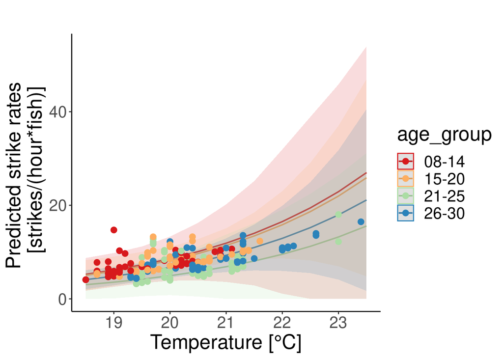

```r
# define some essentials:
visualization.model= zeroinfl(sr~age_group+temp+oxygen+PH|mean_detections_per_frame_20,dist='negbin', data=data)
colors = brewer.pal(4,'Spectral')
data$age_group = factor(data$age_group,levels=c("08-14",'15-20',"21-25",'26-30'))

##### Temperature visreg: #####
# setup a data frame for visreg, i.e., pH and oxygen should be at their median values and we're checking the effect of temperature on the strike rates
new.data = data
new.data = new.data[-which(is.na(new.data$temp)),]
new.data$oxygen = median(data$oxygen)
new.data$PH = median(data$PH)
new.data$model.preds = predict(visualization.model,newdata = new.data) # get model predictions on this new data
# use ggpredict for CIs:
pred = ggpredict(visualization.model,type='zero_inflated',terms=c('temp','age_group'))
pred$group = factor(pred$group,levels=c("08-14",'15-20',"21-25",'26-30'))

g = plot(pred,colors=colors)+#CIs
  geom_point(data=new.data, inherit.aes=F,
                      aes(x=temp,y=model.preds,color=age_group),size=2.5)+
  theme_classic() +
  labs(y='Predicted strike rates \n [strikes/(hour*fish)]', x='Temperature [\u00B0C]',title='')+theme(text=element_text(size=20))
g
```

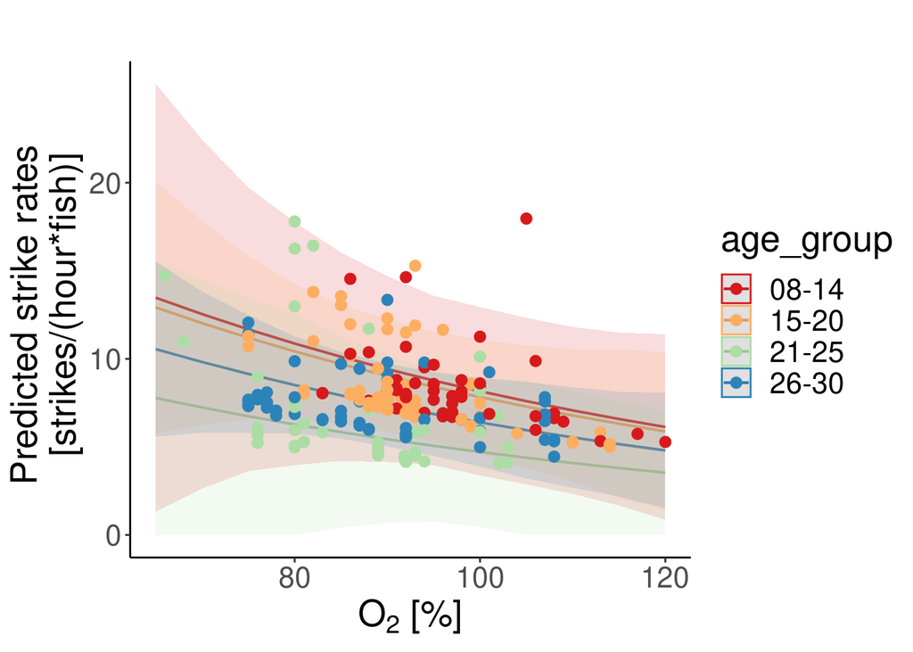

```r
##### Oxygen visreg: ####
new.data = data
new.data = new.data[-which(is.na(new.data$temp)),]
new.data$temp = median(new.data$temp)
new.data$PH = median(data$PH)
new.data$model.preds = predict(visualization.model,newdata = new.data)
# use ggpredict for CIs:
pred = ggpredict(visualization.model,type='zero_inflated',terms=c('oxygen','age_group'))
pred$group = factor(pred$group,levels=c("08-14",'15-20',"21-25",'26-30'))

g = plot(pred,colors=colors)+
  geom_point(data=new.data, inherit.aes=F,
                      aes(x=oxygen,y=model.preds,color=age_group),size=2.5)+
  theme_classic() +
  labs(y='Predicted strike rates \n [strikes/(hour*fish)]',
       x=expression(paste(O[2]," [%]",sep="")),title='')+
  theme(text=element_text(size=20))
g
```

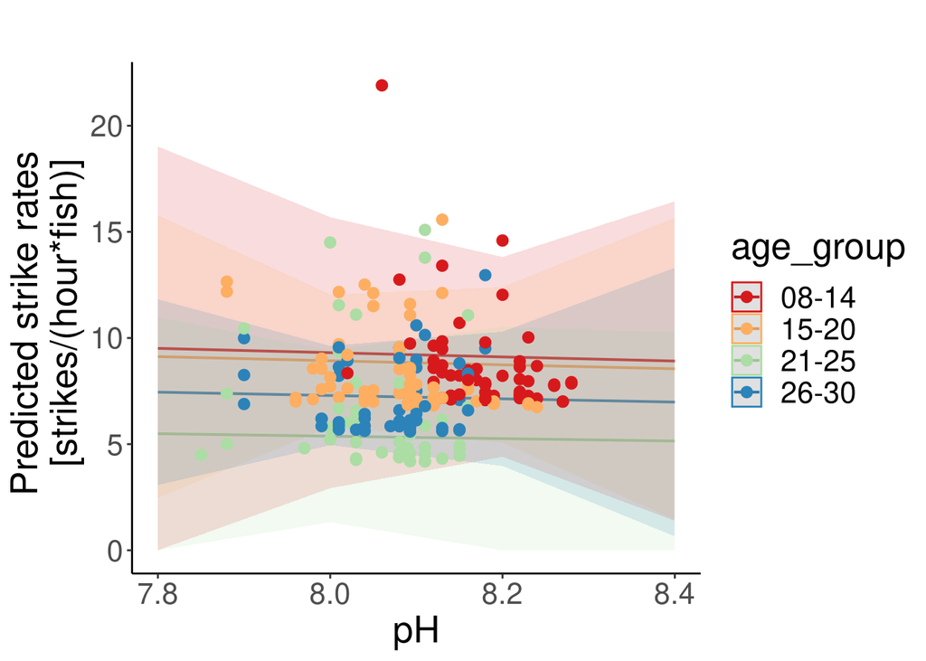

```r
##### pH visreg: #####
new.data = data
new.data = new.data[-which(is.na(new.data$temp)),]
new.data$temp = median(new.data$temp)
new.data$oxygen = median(data$oxygen)
new.data$model.preds = predict(visualization.model,newdata = new.data)
# plot visreg:
colors = brewer.pal(4,'Spectral')

pred = ggpredict(visualization.model,type='zero_inflated',terms=c('PH','age_group'))
pred$group = factor(pred$group,levels=c("08-14",'15-20',"21-25",'26-30'))
#levels(pred$group) = c("08-14",'15-20',"21-25",'26-30')

g = plot(pred,colors=colors)+
  geom_point(data=new.data, inherit.aes=F,
                      aes(x=PH,y=model.preds,color=age_group),size=2.5)+
  theme_classic() +
  labs(y='Predicted strike rates \n [strikes/(hour*fish)]', x='pH',title='')+
  theme(text=element_text(size=20))
g
```